# Assignment 1: plots, bar charts, and filtering

This assignment uses a dataset of all NYC restaurant inspection results from Jan. 1, 2019 - Aug. 30, 2019. Download the file from Blackboard. The original, unfiltered dataset is at https://data.cityofnewyork.us/Health/DOHMH-New-York-City-Restaurant-Inspection-Results/43nn-pn8j.

Information about how restaurants are inspected and graded in NYC is here: https://www1.nyc.gov/assets/doh/downloads/pdf/rii/how-we-score-grade.pdf(https://www1.nyc.gov/assets/doh/downloads/pdf/rii/how-we-score-grade.pdf)

There are a lot of columns in this dataset. To show them all when displaying the dataset, use the following code beforehand (once per notebook): `pd.set_option('display.max_columns', None)`

All plots should have an appropriate title and axes labels.

1. Plot a histogram to visualize the distribution of the inspection scores. You should experiment with the number of bins to find a visualization that shows all major features of the distribution. What do you notice about the distribution, and how do you think that fits with how restaurants are inspected?
2. Plot a bar chart of the distribution of boroughs. In which boroughs are the most/least restaurant inspections?
3. Find the mean score for inspections made in January and the mean score for inspections made in July. From these computations, does the mean score seem to depend on the month? Why do you think this might be?
4. Make a bar chart of the top 15 cuisine types in the dataset.
5. How many different cuisine types are there in the dataset? And what is the most common street?

```python
# Ramish Saqib. This notebook deals with data concerning the inspection scores of restaruants.
```

```python
import matplotlib.pyplot as plt
import pandas as pd
import seaborn as sns
%matplotlib inline
```

```python
pd.set_option('display.max_columns', None)
```

```python
inspection = pd.read_csv("DOHMH_New_York_City_Restaurant_Inspection_Results.csv")
```

```python
inspection.describe()
```

|  | CAMIS | ZIPCODE | SCORE | Latitude | Longitude | Community Board | Council District | Census Tract | BIN | BBL |
| --- | --- | --- | --- | --- | --- | --- | --- | --- | --- | --- |
| count | 1.103640e+05 | 108920.000000 | 106853.000000 | 110260.000000 | 110260.000000 | 108816.000000 | 108816.000000 | 108816.000000 | 1.083150e+05 | 1.102600e+05 |
| mean | 4.663234e+07 | 10696.305013 | 22.297249 | 40.195320 | -72.972523 | 251.406576 | 20.246094 | 29612.160261 | 2.540325e+06 | 2.434134e+09 |
| std | 4.318050e+06 | 596.189676 | 16.588463 | 4.630846 | 8.406504 | 129.875046 | 15.674501 | 31065.666987 | 1.342813e+06 | 1.334352e+09 |
| min | 3.007544e+07 | 10000.000000 | -1.000000 | 0.000000 | -74.248434 | 101.000000 | 1.000000 | 100.000000 | 1.000000e+06 | 1.000000e+00 |
| 25% | 4.147968e+07 | 10022.000000 | 11.000000 | 40.686060 | -73.988944 | 106.000000 | 4.000000 | 8000.000000 | 1.045866e+06 | 1.010540e+09 |
| 50% | 5.001811e+07 | 10474.000000 | 18.000000 | 40.732013 | -73.956292 | 301.000000 | 20.000000 | 17010.000000 | 3.014447e+06 | 3.004410e+09 |
| 75% | 5.007025e+07 | 11231.000000 | 28.000000 | 40.761831 | -73.896083 | 401.000000 | 34.000000 | 42100.000000 | 4.005324e+06 | 4.004358e+09 |
| max | 5.009750e+07 | 12345.000000 | 166.000000 | 40.907329 | 0.000000 | 595.000000 | 51.000000 | 162100.000000 | 5.799501e+06 | 5.270001e+09 |

```python
scores = inspection["SCORE"]
```

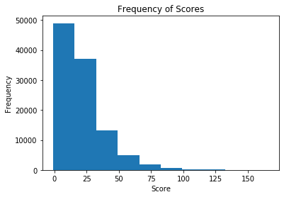

```python
scores.plot.hist()
plt.title("Frequency of Scores")
plt.xlabel("Score")
plt.ylabel("Frequency")
```

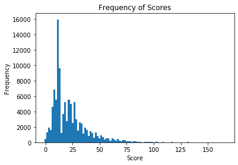

```python
scores.plot.hist(bins = 100)
plt.title("Frequency of Scores")
plt.xlabel("Score")
plt.ylabel("Frequency")
```

```python
# Majority of restaurants score low which is good because the lower the score, the better.
# This fits with how restaurants are expected because the less serious violations only add a few points to your score
```

```python
borough = inspection["BORO"].value_counts()
```

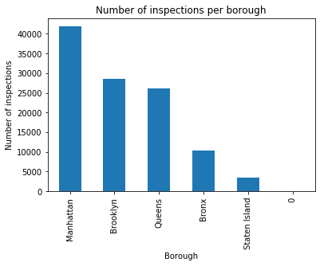

```python
borough.plot.bar()
plt.title("Number of inspections per borough")
plt.xlabel("Borough")
plt.ylabel("Number of inspections")
```

```python
# Manhattan has the most inspections while Staten Island has the least
```

```python
inspection["INSPECTION DATE"] = pd.to_datetime(inspection["INSPECTION DATE"])
```

```python
januaryMonth = inspection["INSPECTION DATE"].dt.month == 1
```

```python
januaryScore = scores[januaryMonth]
```

```python
januaryScore.mean()
```

```
20.332909899283187
```

```python
julyMonth = inspection["INSPECTION DATE"].dt.month == 7
```

```python
julyScore = scores[julyMonth]
```

```python
julyScore.mean()
```

```
26.203096228602604
```

```python
# The mean score was about 6 points higher in July than January
# This may be because it is summer in July, and there are more flies and mosquitoes and such, so restaurants seem to be in worse condition
```

```python
inspection["CUISINE DESCRIPTION"].value_counts()
```

```
American                                                            21688
Chinese                                                             12486
Café/Coffee/Tea                                                      5456
Pizza                                                                5128
Latin (Cuban, Dominican, Puerto Rican, South & Central American)     4696
Mexican                                                              4411
Italian                                                              4283
Caribbean                                                            4180
Japanese                                                             3848
Spanish                                                              3696
Bakery                                                               3233
Chicken                                                              2381
Pizza/Italian                                                        2276
Indian                                                               2040
Asian                                                                1963
Delicatessen                                                         1781
Korean                                                               1710
Jewish/Kosher                                                        1662
Thai                                                                 1591
Juice, Smoothies, Fruit Salads                                       1399
Mediterranean                                                        1273
Donuts                                                               1249
French                                                               1171
Sandwiches                                                           1139
Hamburgers                                                           1107
Middle Eastern                                                        915
Ice Cream, Gelato, Yogurt, Ices                                       888
Seafood                                                               867
Irish                                                                 863
Sandwiches/Salads/Mixed Buffet                                        774
                                                                    ...
Polish                                                                133
Continental                                                           127
Soups & Sandwiches                                                    116
German                                                                115
Australian                                                            110
Brazilian                                                             109
Hotdogs/Pretzels                                                       89
Ethiopian                                                              81
Armenian                                                               72
Pancakes/Waffles                                                       52
Afghan                                                                 46
Moroccan                                                               45
Egyptian                                                               44
Creole/Cajun                                                           43
English                                                                39
Hotdogs                                                                39
Fruits/Vegetables                                                      39
Portuguese                                                             32
Californian                                                            30
Indonesian                                                             29
Southwestern                                                           27
Cajun                                                                  25
Not Listed/Not Applicable                                              24
Iranian                                                                19
Scandinavian                                                           19
Soups                                                                  18
Nuts/Confectionary                                                     13
Chilean                                                                 6
Czech                                                                   6
Basque                                                                  2
Name: CUISINE DESCRIPTION, Length: 84, dtype: int64
```

```python
numCuisineType = inspection["CUISINE DESCRIPTION"].value_counts()
```

```python
top_15_filter = numCuisineType > 1900
```

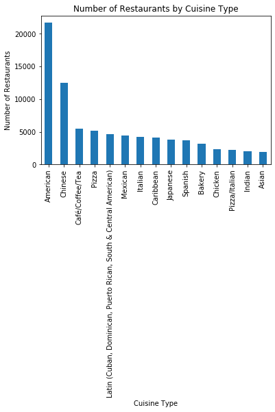

```python
numCuisineType[top_15_filter].plot.bar()
plt.title("Number of Restaurants by Cuisine Type")
plt.xlabel("Cuisine Type")
plt.ylabel("Number of Restaurants")
```

```python
len(inspection["CUISINE DESCRIPTION"].value_counts())
```

```
84
```

```python
# 84 different types of cuisine
```

```python
inspection["STREET"].value_counts()
```

```
BROADWAY                           3805
3RD AVE                            1414
ROOSEVELT AVE                      1220
8TH AVE                            1167
5TH AVE                            1154
2ND AVE                            1151
NORTHERN BLVD                       958
3 AVENUE                            937
1ST AVE                             863
5 AVENUE                            790
JAMAICA AVE                         781
7TH AVE                             740
LEXINGTON AVE                       737
9TH AVE                             692
QUEENS BLVD                         673
AMSTERDAM AVE                       671
8 AVENUE                            629
2 AVENUE                            610
ROOSEVELT AVENUE                    599
NORTHERN BOULEVARD                  576
FULTON ST                           572
NOSTRAND AVE                        565
GRAND ST                            547
MAIN ST                             531
FLATBUSH AVE                        531
AVENUE U                            513
9 AVENUE                            513
7 AVENUE                            494
JAMAICA AVENUE                      489
AMSTERDAM AVENUE                    487
                                   ...
235TH ST                              1
NORMAN AVENUE                         1
55 STREET                             1
CONSELYEA ST                          1
CHRYSTIE ST/PUBLIC KITCHEN            1
WEST 32ND STREET                      1
E 146TH ST                            1
126 TH  & ROOSEVELT AVENUE            1
LAGUARDIA INTERNATIONAL AIRPORT       1
LAGUARDIA TERMINAL C                  1
32 PLACE                              1
THAMES STREET                         1
ALBEE SQUARE W                        1
FATHER CAPPDANO BLVD                  1
PUTNAM STREET                         1
HIGH LINE PK W 15TH ST                1
4 AVE                                 1
25 AVENUE                             1
ARDEN AVE                             1
TERMINAL 5                            1
AND ROOSEVELT AVE                     1
EAST 76 STREET                        1
HUNTERS POINT AVE                     1
NOME AVENUE                           1
168 STREET                            1
FOREST PARK DR                        1
HURON STREET                          1
WEST 57 STREET                        1
METRO TECH CENTER SOUTH               1
BAY RIDGE PARKWAY                     1
Name: STREET, Length: 2927, dtype: int64
```

```python
# Most common street is broadway
```